# Assignment 4, Task 2

Author

Gabriel Ingman

# Agglomerative Hierarchical Clustering

[figure not shown]

Godzilla off the coast of Santa Barbara (Microsoft CoPilot AI generated)

## Data Overview & Summary

From the abstract: ’The data package contains stream chemistry measurements taken in Santa Barbara area watersheds, beginning in the year 2000… Stream water samples are collected weekly during non-storm flows in winter, and bi-weekly during summer. During winter storms, samples are collected hourly (rising limb) or at 2-4 hour intervals (falling limb).”

The purpose of this task is to perform hierarchical clustering (with complete linkage) on the stream dataset, and create a dendrogram that explores relationships between observations in the dataset. Specifically, we are looking for clusters, or places on a graph where observations group together.

## Pseudocode for Task 1

First, I load in the data and clean it for analysis by accounting for the -999 values, by converting them in to N/A values. Then, I had to deal with the numerous N/A values. First, I visually inspected the data to determine where the N/A values were happening. Then, I filtered out any columns with more than 50% N/A values. Once that was done, I had to figure out what to do with the N/A values that remained. I decided to summarize them using the na.rm() command.

## Real Code for Task 1

### Part 1: Data Cleaning

```r
library(tidyverse)
library(here)
library(janitor)
library(NbClust)
library(cluster)
library(factoextra)
library(dendextend)
library(ggdendro)
library(patchwork)
```

```r
#loading in data, converting -999 values to NA
sb_stream_raw <- read.csv(here('data', 'sbc_lter_registered_stream_chemistry.csv')) %>%
  clean_names() %>%
  mutate(across(where(is.numeric), ~na_if(., -999)))

#summary(sb_stream_raw)
#nh4_u_m NAs: 203
#no3_u_m NAs: 149
#po4_u_m NAs: 167
#tdn_u_m NAs: 5034
#tdp_u_m NAs: 5801
#tpc_u_m NAs: 16521
#tpn_u_m NAs: 16521
#tpp_u_m NAs: 17046
#tss_mgper_liter NAs: 14376
#spec_cond_u_spercm NAs: 924
```

```r
#defining a 50% threshold object. we will need this later.
threshold <- 0.5

na_values <- colMeans(is.na(sb_stream_raw))

#Filtered the dataset to only contain numeric columns with 50% or less NA values as per our threshold.

sb_stream_filtered <- sb_stream_raw[, na_values <= threshold]
```

```r
#using na.rm = TRUE to deal with the NA values, and made proper titles

sb_stream_grouped <- sb_stream_filtered %>%
  group_by(site_code) %>%
  summarize(
    "Ammonium" = mean(nh4_u_m, na.rm = TRUE),
    "Nitrate" = mean(no3_u_m, na.rm = TRUE),
    "Phosphorous" = mean(po4_u_m, na.rm = TRUE),
    "Dissolved Nitrogen" = mean(tdn_u_m, na.rm = TRUE),
    "Dissolved Phosphorous" = mean(tdp_u_m, na.rm = TRUE),
    "Specific Conductivity" = mean(spec_cond_u_spercm, na.rm = TRUE)) %>%
  drop_na()
```

### Part 2: Clustering

```r
#selecting only the numeric columns for the dataset I will use for clustering

sb_stream_scale <- sb_stream_grouped %>%
  select(2:7) %>%
  scale()

#add in the titles again

row.names(sb_stream_scale) <- sb_stream_grouped$site_code
```

```r
distance_object <- dist(sb_stream_scale, method = 'euclidean')

sbs_clusters <- hclust(distance_object, method = 'complete')
```

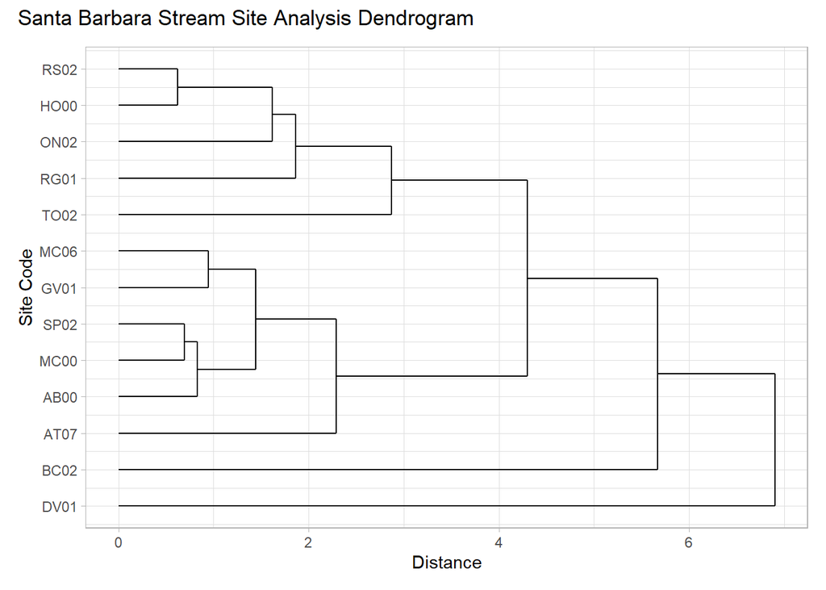

```r
sbs_dendrogram <- ggdendrogram(sbs_clusters,
                               rotate = TRUE) +
  theme_light() +
  labs(x = 'Site Code', y = 'Distance')

sbs_dendrogram + plot_annotation(
  title = 'Santa Barbara Stream Site Analysis Dendrogram'
)
```

## Takeaways from Dendrogram

- The most similar sites, i.e. the ones with the least Euclidean distance between them, are: RS02 & HO00, and SP02 & MC00.
- The most dissimilar sites, i.e. the ones with the most Euclidean distance between them, are: DV01 and every other site. A close second is site BC02.
- I’d be curious to learn which of the variables- chemical concentration, conductivity, etc- impacted sites DV01 and BC02 being so dissimilar to the rest of the sites used for analysis in this task.

## Data Citation

Santa Barbara Coastal LTER and J. Melack. 2019. SBC LTER: Land: Stream chemistry in the Santa Barbara Coastal drainage area, ongoing since 2000 ver 16. Environmental Data Initiative. https://doi.org/10.6073/pasta/67a558a24ceed9a0a5bf5e46ab841174 (Accessed 2024-03-16).